# Orvac - Discrete surveillance

# 1 Preamble

Observing hospitalisation events[^1] is a discrete process. We will observe whether a participant has had an event at follow up 1, follow up 2 and every 6 months subsequent to randomisation with the event occuring at some point prior to our surveillance visit. However, after the first interim, the interim analyses happen at the latest of 3 months apart. This limits the extent to which we can see whether events have happened. The following figures provide a simplified example of what we might find in practice.

# 2 Generating data

```r
day_to_month <- function(x){return(x / days_per_month)}
# colourblind palette
cbPalette <- c("#999999", "#E69F00", "#56B4E9", "#009E73",
               "#F0E442", "#0072B2", "#D55E00", "#CC79A7")

set.seed(2)
n <- 1000
interim_period <- 3
people_per_interim_period <- 50
months_per_person <- interim_period / people_per_interim_period
max_age_fu_months <- 36
median_time_to_event <- 20
days_per_month <- 365.25/12

dt <- data.table(id = numeric(n),
                 accrt = numeric(n),      # time of randomisation
                 age_months = numeric(n), # age at time of randomisation
                 trial_months_at_max_age = numeric(n),
                 evtt = numeric(n),
                 cent_at_interim = rep(NA, n),
                 cent_at_max = rep(NA, n),
                 obst = rep(NA, n),
                 cen = rep(NA, n)) # censoring variable (0 = not censored, 1 = censored)

dt[,id := 1:n]

# age is at time of randomisation, i.e. at their accrual time
dt[,age_months := rtruncnorm(n,6,12,6.5,1)]
# linear accrual (dream on)
dt[,accrt := (id - 1) * months_per_person]
# the limiting month of the trial at which fu ceases for each individual
dt[,trial_months_at_max_age := max_age_fu_months - age_months + accrt]

# generate events following exponential distribution
mu <- log(2)/median_time_to_event
dt[, evtt := stats::rexp(n, rate = mu) + accrt]

dt[, fu1 := accrt + day_to_month(14)]
dt[, fu2 := accrt + day_to_month(28)]
dt[, surveillance1 := accrt + 6]
dt[, surveillance2 := accrt + 12]
dt[, surveillance3 := accrt + 18]
dt[, surveillance4 := accrt + 24]
```

# 3 Visualisation

Here is the whole data set with the horizontal lines showing the time to event (from randomisation) for each individual.

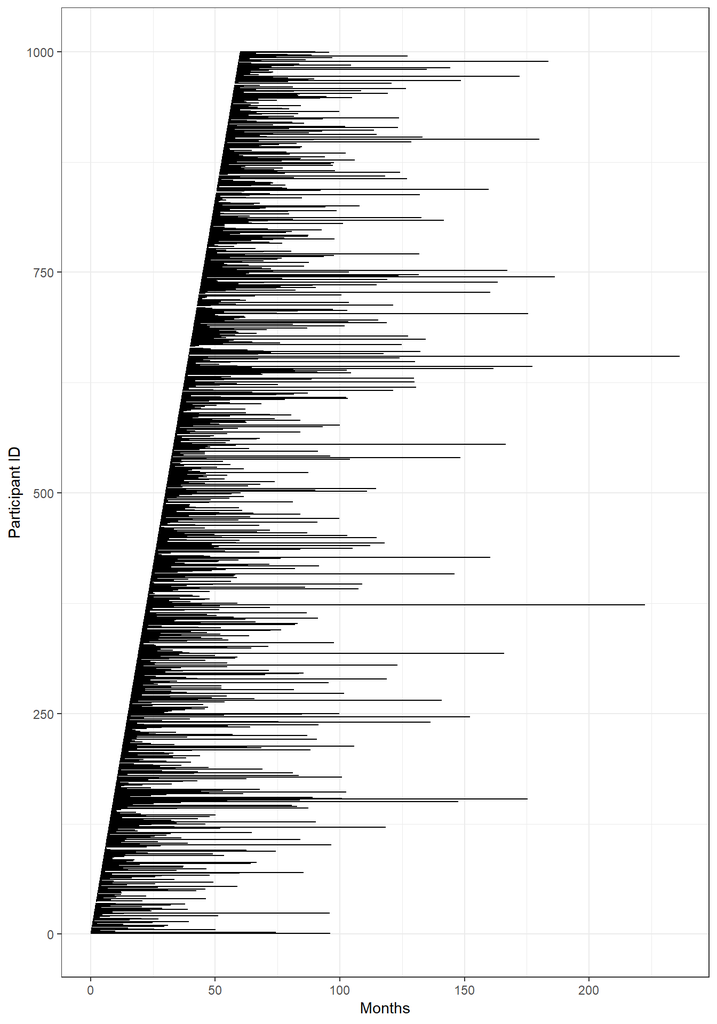

Under the accrual rates assumed here, the 50th participant enters the study 2.94 months after the start. They happen to be around 6.4 months old. If we make the blanket assumption that follow up 1 happens 14 days after randomisation and follow up 2 happens at day 28 and then the blood tests for each participant are back 14 days later, then the first interim happens 42 days after randomisation of participant 50. So, the first interim happens around 4.32 months and subsequent interims occur every 3 months after that.

The figure below shows the event data for the first 50 participants and the vertical dashed lines show when the interim analyses occur. The small black dots represent the time at which we observe the medical data for each participant, i.e. follow up 1, 2 and passive 6 monthly surveillance.

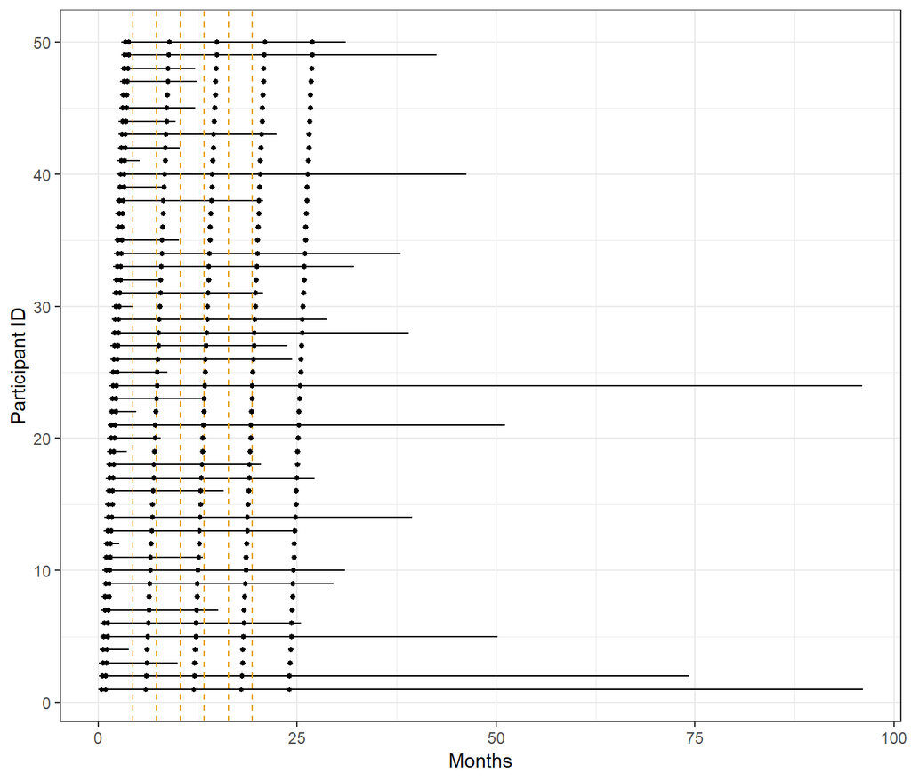

Now just focus on participants 20 to 30. What do you see?

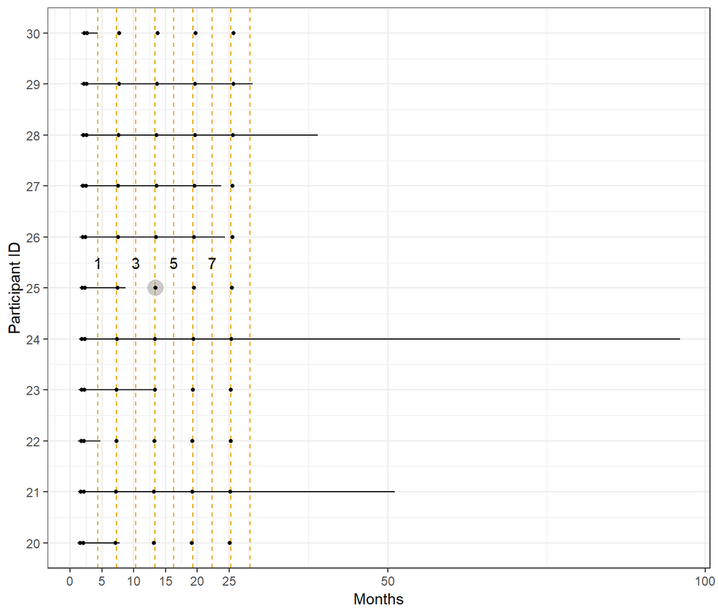

What should be obvious is the disconnect between the interim analyses and the surveillance frequency. For example, look at participant 25 – they enter the study at 1.44 months and have a medical presentation at 8.7 months, just before the third interim at 10.3 months. However, under the proposed surveillance frequency, we will not look at the medical records for this participant until 13.4 months (dot with the grey shading). Now, given that the fourth interim occurs at 13.3 we will not include this event until the 5th interim analysis – up until that time, this participant will be censored.

# 4 Conclusion

This was a first pass through the gnarly problem of observing events at discrete timepoints when there are large gaps between surveillance visits and analyses occuring between the visit times. I simply wanted to visualise unusual scenarios that might occur in practice.

Participants like ID 25, will be censored with censoring time equal to the last surveillance visit for this individual until their event is observed at a subsequent surveillance visit.

The impact is on the rate at which new information arises, which will be a multidimensional function of accrual, event and censoring rates. In turn, this plausibly impacts power.

[^1]: An event is the time from randomisation to first medical presentation with RV gastro.